# housing_Lab3

### =====================================================================

### COURSE NAME: CSCN8010-LAB3

### ADI : TESSA NEJLA AYVAZOGLU

### STD NO: 8686601

### DATE : 26/01/2024

### =====================================================================

### 1.Framing the Problem - Describe the goal of this report (0.4 point).

### Practical Lab 3 - Univariate Linear Regresion:

In this lab you will train your first machine learning model in our course - a univariate linear regression model. You are asked to run a linear regression between the median house value (dependent variable) and each of the following independent variables.

- You should run three models, one for each independent variable:
  - median income
  - population
  - number of households

#### Format your HTML as a short report.

- It should be divided into short sections, each one with a Markdown title:
  - Framing the Problem - Describe the goal of this report (0.4 point).
  - Getting the Data - hyperlinking to the source (0.1 point) and loading into Pandas (0.1 point).
  - Exploratory Data Analysis (EDA):
    1. Explore statistics (e.g. using Pandas `describe` function) (0.2 point)
    2. Describe the 4 variables used in this lab. Review the range of the data for each variable, and other issues you notice (0.3 point)
    3. Create three Seaborn scatter plots of median house value vs. median income, population and number of households. There should be one scatter plot per each independent variable. Add a title to each graph (using Seaborn). Provide textual review of what you see in these graphs (relevant insights). (0.6 points).
  - Run three linear regressions (fitting) between (1.2 points):
    1. median house value vs. median income.
    2. median house value vs. population.
    3. median house value vs. number of households.
  - Summarize in a table, for each of the three models:
    1. intercept and slope (0.5 point).
    2. Mean Squared Error - the loss (0.3 point).
    3. Mean Absolute Error (0.3 point).
  - Plot the resulting line on top of the scatter data for each of the three models (three separate graphs) (1 point).
  - Provide a conclusion about the goodness-of-fit, and other insights you might have (1 point).
- Due on Jan 27, 2024 11:59 PM.
- Available on Jan 23, 2024 12:01 PM Access restricted before availability starts.
- Available until Jan 30, 2024 11:59 PM Access restricted after availability ends.

## 2.Getting the Data - hyperlinking to the source (0.1 point) and loading into Pandas (0.1 point).

```python
import pandas as pd
```

```python
housing = pd.read_csv('C:/Users/Tessa/Conestoga/CSCN8010-Tessa/CSCN8010-labs/Data/housing.csv')
```

```python
housing.describe()
```

|  | longitude | latitude | housing_median_age | total_rooms | total_bedrooms | population | households | median_income | median_house_value |
| --- | --- | --- | --- | --- | --- | --- | --- | --- | --- |
| count | 20640.000000 | 20640.000000 | 20640.000000 | 20640.000000 | 20433.000000 | 20640.000000 | 20640.000000 | 20640.000000 | 20640.000000 |
| mean | -119.569704 | 35.631861 | 28.639486 | 2635.763081 | 537.870553 | 1425.476744 | 499.539680 | 3.870671 | 206855.816909 |
| std | 2.003532 | 2.135952 | 12.585558 | 2181.615252 | 421.385070 | 1132.462122 | 382.329753 | 1.899822 | 115395.615874 |
| min | -124.350000 | 32.540000 | 1.000000 | 2.000000 | 1.000000 | 3.000000 | 1.000000 | 0.499900 | 14999.000000 |
| 25% | -121.800000 | 33.930000 | 18.000000 | 1447.750000 | 296.000000 | 787.000000 | 280.000000 | 2.563400 | 119600.000000 |
| 50% | -118.490000 | 34.260000 | 29.000000 | 2127.000000 | 435.000000 | 1166.000000 | 409.000000 | 3.534800 | 179700.000000 |
| 75% | -118.010000 | 37.710000 | 37.000000 | 3148.000000 | 647.000000 | 1725.000000 | 605.000000 | 4.743250 | 264725.000000 |
| max | -114.310000 | 41.950000 | 52.000000 | 39320.000000 | 6445.000000 | 35682.000000 | 6082.000000 | 15.000100 | 500001.000000 |

## 3.Exploratory Data Analysis (EDA):

- 1.Explore statistics (e.g. using Pandas `describe` function) (0.2 point)
- 2.Describe the 4 variables used in this lab. Review the range of the data for each variable, and other issues you notice (0.3 point)
- 3.Seaborn Scatter plots of median house value vs. median income, population and number of households. There should be one scatter plot per each independent variable. Add a title to each graph (using Seaborn). Provide textual review of what you see. (0.6 points).

```python
housing[["median_income", "population", "households"]]
```

|  | median_income | population | households |
| --- | --- | --- | --- |
| 0 | 8.3252 | 322 | 126 |
| 1 | 8.3014 | 2401 | 1138 |
| 2 | 7.2574 | 496 | 177 |
| 3 | 5.6431 | 558 | 219 |
| 4 | 3.8462 | 565 | 259 |
| ... | ... | ... | ... |
| 20635 | 1.5603 | 845 | 330 |
| 20636 | 2.5568 | 356 | 114 |
| 20637 | 1.7000 | 1007 | 433 |
| 20638 | 1.8672 | 741 | 349 |
| 20639 | 2.3886 | 1387 | 530 |

20640 rows × 3 columns

```python
housing[["median_income", "population", "households"]].mean()
```

```
median_income       3.870671
population       1425.476744
households        499.539680
dtype: float64
```

```python
housing[["median_income", "population", "households"]].median()
```

```
median_income       3.5348
population       1166.0000
households        409.0000
dtype: float64
```

```python
housing.agg (
{
   "median_income" : ["min", "max", "median", "mean", "std" ],
   "population" :    ["min", "max", "median", "mean", "std" ],
   "households" :    ["min", "max", "median", "mean", "std" ]

}

)
```

|  | median_income | population | households |
| --- | --- | --- | --- |
| min | 0.499900 | 3.000000 | 1.000000 |
| max | 15.000100 | 35682.000000 | 6082.000000 |
| median | 3.534800 | 1166.000000 | 409.000000 |
| mean | 3.870671 | 1425.476744 | 499.539680 |
| std | 1.899822 | 1132.462122 | 382.329753 |

```python
housing.agg (
{
   "median_income" : ["min", "max", "median", "mean", "std" ],
   "population" :    ["min", "max", "median", "mean", "std" ],
   "households" :    ["min", "max", "median", "mean", "std" ]

}

)
```

|  | median_income | population | households |
| --- | --- | --- | --- |
| min | 0.499900 | 3.000000 | 1.000000 |
| max | 15.000100 | 35682.000000 | 6082.000000 |
| median | 3.534800 | 1166.000000 | 409.000000 |
| mean | 3.870671 | 1425.476744 | 499.539680 |
| std | 1.899822 | 1132.462122 | 382.329753 |

This folowing code is explanation :

Let’s have a quick look at the distribution of these features by plotting their histograms.

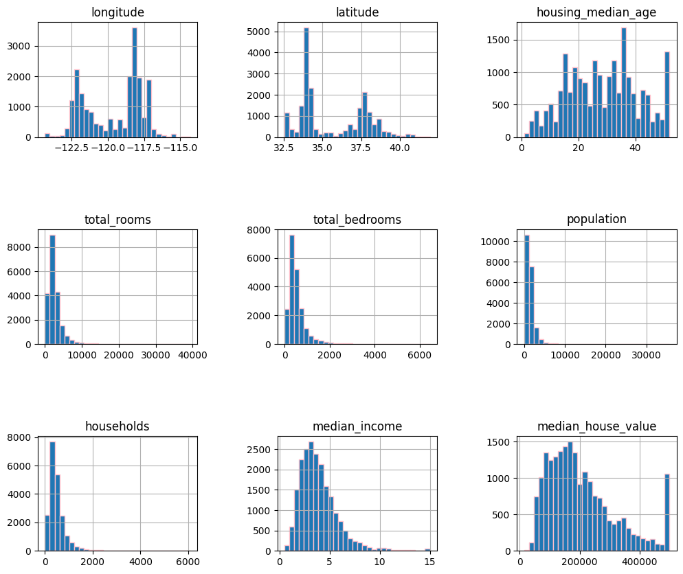

```python
import matplotlib.pyplot as plt
housing.hist(figsize=(12, 10), bins=30, edgecolor="pink")
plt.subplots_adjust(hspace=0.8, wspace=0.5)
```

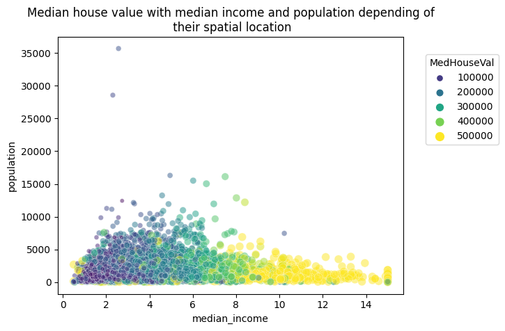

```python
import seaborn as sns

sns.scatterplot(
    data=housing,
    x="median_income",
    y="population",
    size="median_house_value",
    hue="median_house_value",
    palette="viridis",
    alpha=0.5,
)
plt.legend(title="MedHouseVal", bbox_to_anchor=(1.05, 0.95), loc="upper left")
_ = plt.title("Median house value with median income and population depending of\n their spatial location")
```

[figure not shown]

```python
import seaborn as sns

sns.scatterplot(
    data=housing,
    x="median_income",
    y="median_house_value",
    size="median_house_value",
    hue="median_house_value",
    palette="viridis",
    alpha=0.5,
)
plt.legend(title="MedHouseVal", bbox_to_anchor=(1.05, 0.95), loc="upper left")
_ = plt.title("Median House Value depending of\n their median income ")
```

[figure not shown]

```python
import seaborn as sns

sns.scatterplot(
    data=housing,
    x="population",
    y="median_house_value",
    size="median_house_value",
    hue="median_house_value",
    palette="viridis",
    alpha=0.5,
)
plt.legend(title="MedHouseVal", bbox_to_anchor=(1.05, 0.95), loc="upper left")
_ = plt.title("Median House Value depending of\n their population")
```

[figure not shown]

```python
import seaborn as sns

sns.scatterplot(
    data=housing,
    x="households",
    y="median_house_value",
    size="median_house_value",
    hue="median_house_value",
    palette="viridis",
    alpha=0.5,
)
plt.legend(title="MedHouseVal", bbox_to_anchor=(1.05, 0.95), loc="upper left")
_ = plt.title("Median House Value depending of\n their households")
```

## 4.Run three linear regressions fitting between (1.2 points)

```python
from sklearn.linear_model import LinearRegression
```

```python
X_income = housing[['median_income']]
X_population = housing[['population']]
X_households = housing[['households']]

y = housing['median_house_value']
```

```python
# Linear regression for median house value vs. median income
model_income = LinearRegression()
model_income.fit(X_income, y)
# Example: Print coefficients for the median income model
print("Coefficient for Median Income:", model_income.coef_[0])
print("Intercept:", model_income.intercept_)

# Linear regression for median house value vs. population
model_population = LinearRegression()
model_population.fit(X_population, y)
# Example: Print coefficients for the median income model
print("Coefficient for population:", model_population.coef_[0])
print("Intercept:", model_population.intercept_)

# Linear regression for median house value vs. number of households
model_households = LinearRegression()
model_households.fit(X_households, y)
# Example: Print coefficients for the median income model
print("Coefficient for households:", model_households.coef_[0])
print("Intercept:", model_households.intercept_)
```

```
Coefficient for Median Income: 41793.849201896286
Intercept: 45085.5767032679
Coefficient for population: -2.511752774615085
Intercept: 210436.26207627333
Coefficient for households: 19.872775155643875
Intercept: 196928.57716233088
```

## 5.Summarize in a table, for each of the three models:

```python
from sklearn.metrics import mean_squared_error, mean_absolute_error

# Create a DataFrame to store the summary
summary_data = {
    'Model': ['Median Income', 'Population', 'Number of Households'],
    'Intercept': [],
    'Slope': [],
    'Mean Squared Error': [],
    'Mean Absolute Error': []
}

# Function to calculate metrics and update the summary
def update_summary(model, independent_variable, y_true):
    y_pred = model.predict(independent_variable)
    mse = mean_squared_error(y_true, y_pred)
    mae = mean_absolute_error(y_true, y_pred)

    summary_data['Intercept'].append(model.intercept_)
    summary_data['Slope'].append(model.coef_[0])
    summary_data['Mean Squared Error'].append(mse)
    summary_data['Mean Absolute Error'].append(mae)

# Update summary for Median Income model
update_summary(model_income, X_income, y)

# Update summary for Population model
update_summary(model_population, X_population, y)

# Update summary for Number of Households model
update_summary(model_households, X_households, y)

# Create a DataFrame from the summary data
summary_df = pd.DataFrame(summary_data)

# Print the summary table
print(summary_df)
```

```
                  Model      Intercept         Slope  Mean Squared Error
0         Median Income   45085.576703  41793.849202        7.011312e+09  \
1            Population  210436.262076     -2.511753        1.330741e+10
2  Number of Households  196928.577162     19.872775        1.325778e+10

   Mean Absolute Error
0         62625.933791
1         91153.820095
2         90802.743243
```

## 6.Plot the resulting line on top of the scatter data for each of the three models (three separate graphs) (1 point)

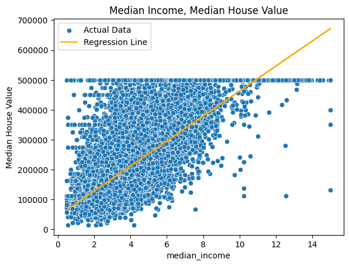

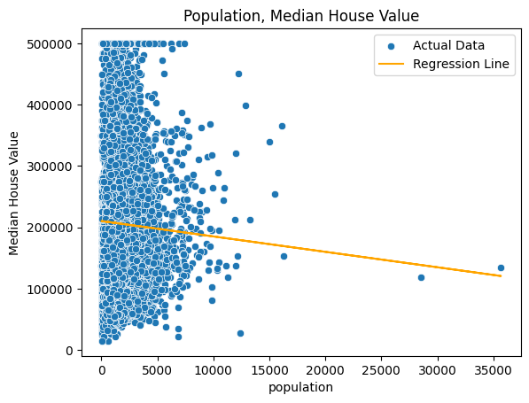

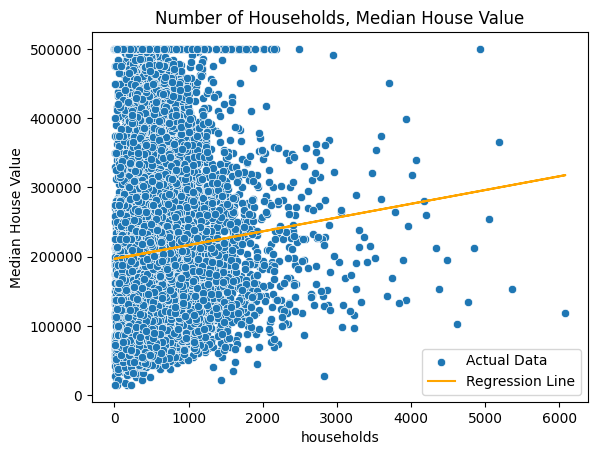

```python
import matplotlib.pyplot as plt
import seaborn as sns

# plot scatter data and regression line
def plot_scatter_with_regression_line(model, independent_variable, y_true, title):
    sns.scatterplot(x=independent_variable.iloc[:, 0], y=y_true, label='Actual Data' )
    # Regression line
    x_range = independent_variable.iloc[:, 0]
    y_pred = model.predict(independent_variable)
    plt.plot(x_range, y_pred, color='orange', label='Regression Line')

    # Set plot properties
    plt.title(title)
    plt.xlabel(independent_variable.columns[0])
    plt.ylabel('Median House Value')
    plt.legend()
    plt.show()

# Plot for Median Income model
plot_scatter_with_regression_line(model_income, X_income, y, 'Median Income, Median House Value')

# Plot for Population model
plot_scatter_with_regression_line(model_population, X_population, y, 'Population, Median House Value')

# Plot for Number of Households model
plot_scatter_with_regression_line(model_households, X_households, y, 'Number of Households, Median House Value')
```

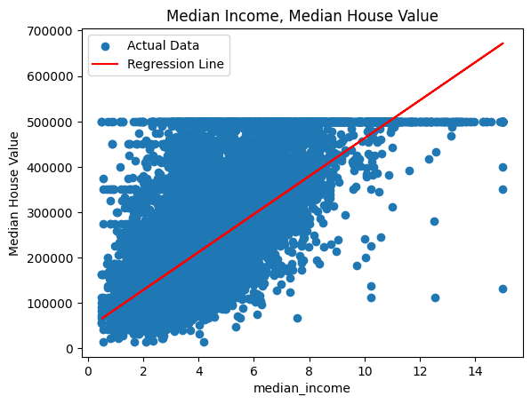

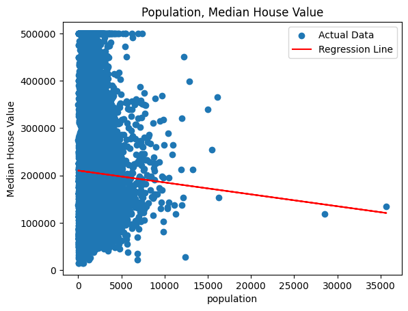

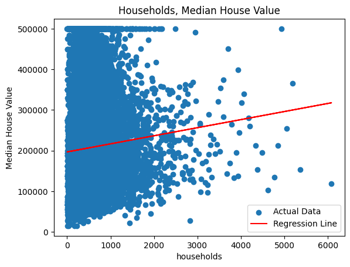

```python
import matplotlib.pyplot as plt

# Assuming you have already fitted the linear regression models
# model_income, model_population, model_households

# Function to plot scatter data and regression line
def plot_scatter_with_regression_line(model, independent_variable, y_true, title):
    # Scatter plot
    plt.scatter(x=independent_variable.iloc[:, 0], y=y_true, label='Actual Data')

    # Regression line
    x_range = independent_variable.iloc[:, 0]
    y_pred = model.predict(independent_variable)
    plt.plot(x_range, y_pred, color='red', label='Regression Line')

    # Set plot properties
    plt.title(title)
    plt.xlabel(independent_variable.columns[0])
    plt.ylabel('Median House Value')
    plt.legend()
    plt.show()

# Plot for Median Income model
plot_scatter_with_regression_line(model_income, X_income, y, 'Median Income, Median House Value')

# Plot for Population model
plot_scatter_with_regression_line(model_population, X_population, y, 'Population, Median House Value')

# Plot for Number of Households model
plot_scatter_with_regression_line(model_households, X_households, y, 'Households, Median House Value')
```

## 7.Provide a conclusion about the goodness-of-fit, and other insights you might have (1 point)

### In Summary:

- The goodness-of-fit analysis for three linear regression models revealed valuable insights into the relationships between independent variables (median income, population, and households) and the dependent variable (median house value) in the California Housing Prices Datasets.

### In summary:

- The linear regression models provide valuable insights into how specific factors influence housing prices. However, it's essential to acknowledge that other factors not considered in this analysis may contribute to variations in median house values. Further exploration and refinement of the models could enhance their predictive capabilities, leading to a more comprehensive understanding of the dataset.